# 머신러닝과 4차 산업혁명

데이터과학자 이광춘

11

# 글로벌 무역현황

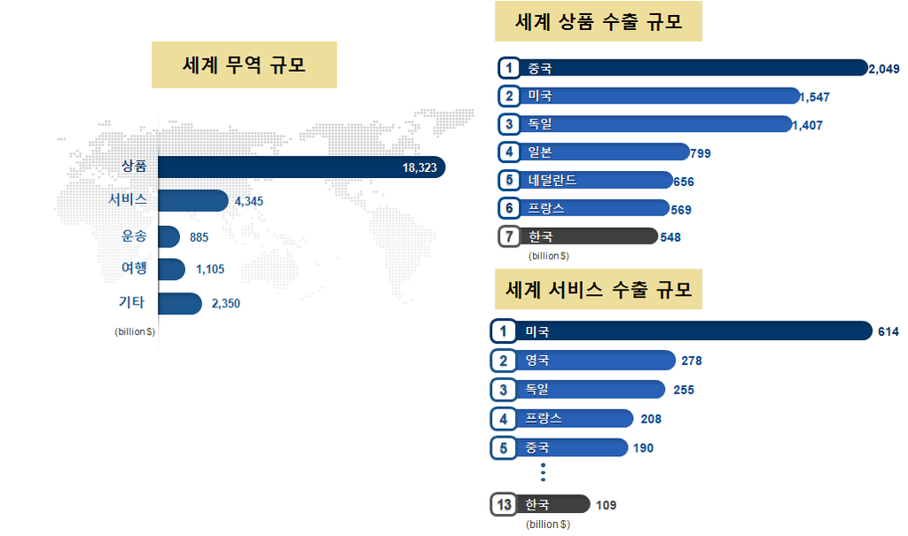

[World Trade Organization (2013), UNWTO Annual Report 2013](http://www.wto.org/english/res_e/booksp_e/anrep_e/anrep13_e.pdf)

# 가치(Value) 원천

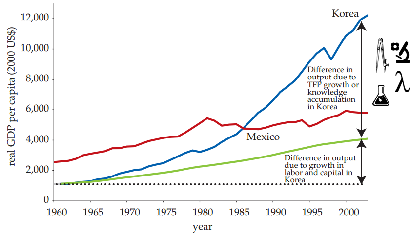

세계은행(World Bank)과 한국개발연구원(KDI)은 약 2년여 기간의 공동연구를 통해 1960-2005 년간 한국 경제발전 과정에 관한 보고서를 출간했다. 경제성장이 지속되기 위해서는 생산성 증가가 대단히 중요하고, 1960년 이후 한국경제의 성공은 광의의 지식축적에 기인한 것으로 1960-2005년 사이 한국의 실질 1인당GDP의 75%가 광의의 지식축적에 기인한 것으로 분석했다.

# 사고체계의 진화

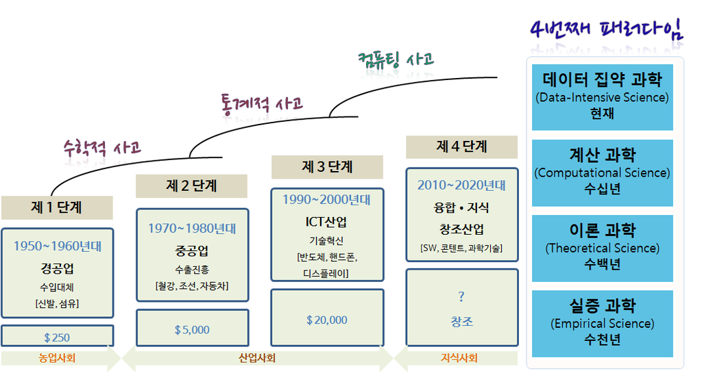

- 수학적 사고(Mathematical Thinking)
- 통계적 사고(Experimental Thinking)
- 컴퓨팅 사고(Computational Thinking)

[Wing, Jeannette M. “Computational thinking.” Communications of the ACM 49.3 (2006): 33-35.](http://research-srv.microsoft.com/en-us/um/redmond/events/asiafacsum2012/day1/Jeannette_Wing.pdf)

# 4번째 패러다임

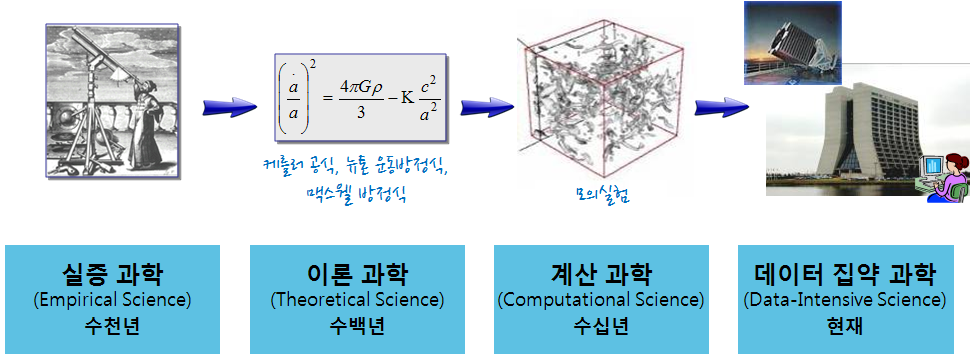

# xwMOOC 오픈 컴퓨터

[video not shown]

# 자동차 클러스터 사례

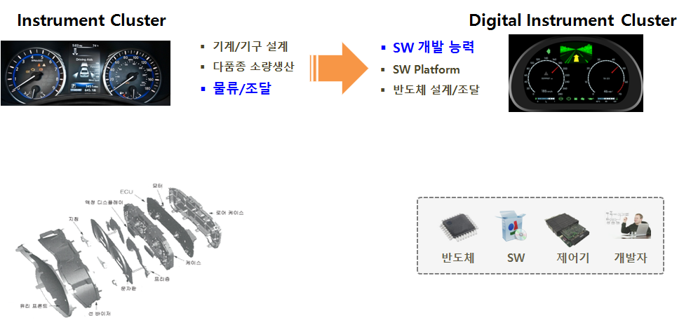

> 기계와 더불어 사는 한국인; 기계와의 경쟁…

> **xwMOOC**

# 수직적 시장 → 인공지능 시장

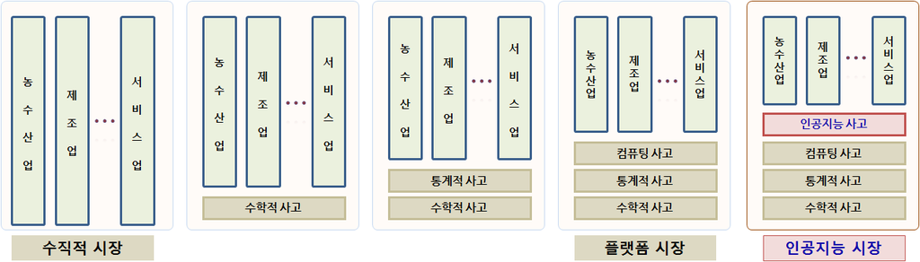

- 수직적(Vertical) 시장 → 플랫폼(Platform) 시장 → 인공지능(AI) 마켓으로

# 한국 기업(?) vs. AI기반 기업

[figure not shown]

# 산업역군(?)

[video not shown]

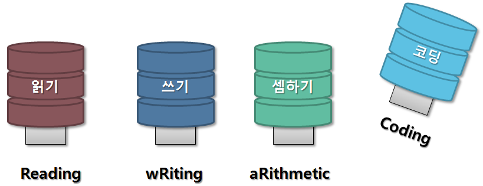

[MATT RICHTEL, “Reading, Writing, Arithmetic, and Lately, Coding”“, The New York Time, MAY 10, 2014](http://www.nytimes.com/2014/05/11/us/reading-writing-arithmetic-and-lately-coding.html)

> “AI is a superpower!!!”, 인공지능을 체득하면 슈퍼파워를 손에 쥘 것이다.

> **Andrew Ng**

# 스타트업 제품 개발

[figure not shown]

# 스타트업 제품 개발 프로세스

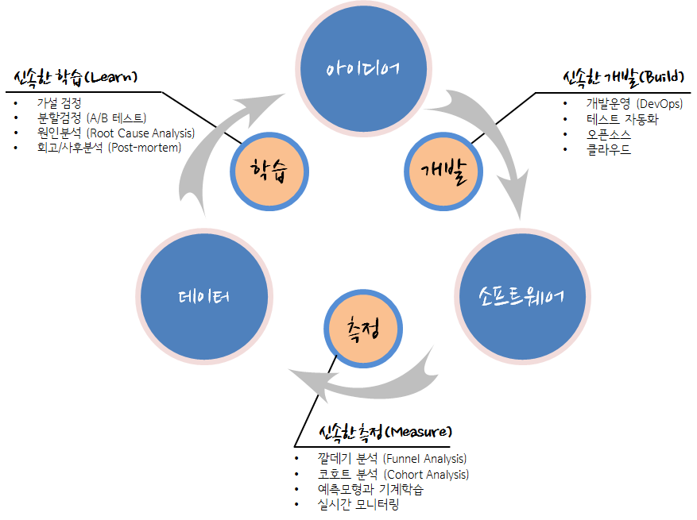